# MTH6139 Time Series

Coursework 1

Franz De Guzman

March 2026

# Introduction

Historically, the price of gold has been an effective indicator of global financial performance and market stability. It can be affected by a range of factors such as inflation, interest rates, fluctuating currencies and uncertainty in the economy. During periods of crisis, investors see gold as a safe-haven asset, leading to increases in price.

Through this project, I decided to analyse the price of gold, recorded each month, since 1833 with the aim of identifying the long-term trends and patterns over a long period. In doing so, we may begin to observe how the price of gold has evolved to reflect changes in market conditions and economic stability.

To achieve this analysis, I used Meta’s Prophet Forecasting Model to model the time series and predict the trends and future behaviours as gold prices continue to evolve.

# 1. Dataset

```r
# Importing libraries

library(prophet)
library(readr)
library(dplyr)

# Reading the Dataset

goldprice_data <- read_csv("data/priceAU.monthly.csv")
head(goldprice_data)
```

```
## # A tibble: 6 × 2
##   Date    Price
##   <chr>   <dbl>
## 1 1833-01  18.9
## 2 1833-02  18.9
## 3 1833-03  18.9
## 4 1833-04  18.9
## 5 1833-05  18.9
## 6 1833-06  18.9
```

The dataset containing the historical price of gold was compiled through data provided by the World Bank.

# 2. Preparation of Data for Prophet

```r
# Renaming Date and Price Columns to be compatible with Prophet

gold_prophet <- goldprice_data %>%
    rename(ds = Date, y=Price)

# Changing the date format from YYYY-MM to YYYY-MM-DD, to be compatible in R

gold_prophet$ds <- as.Date(paste0(gold_prophet$ds, "-01"))

head(gold_prophet)
```

```
## # A tibble: 6 × 2
##   ds             y
##   <date>     <dbl>
## 1 1833-01-01  18.9
## 2 1833-02-01  18.9
## 3 1833-03-01  18.9
## 4 1833-04-01  18.9
## 5 1833-05-01  18.9
## 6 1833-06-01  18.9
```

# 3. Explanatory Analysis

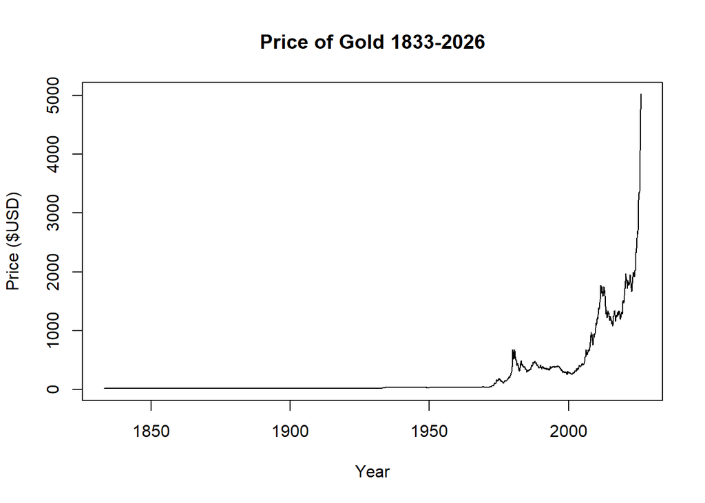

```r
# Plotting the Price of Gold 1833-2026

plot(gold_prophet$ds,
     gold_prophet$y,
     type="l",
     main="Price of Gold 1833-2026",
     xlab="Year",
     ylab="Price ($USD)")
```

The change in price of gold before 1970 appears to be flat with very little variation in comparison to modern fluctuations. As a result of displaying a large dataset in one graph, it is difficult to accurately identify patterns and behaviours of the price of gold. Therefore, we will also plot graphs to focus on gold prices between 1833-1970 and 1970-2026.

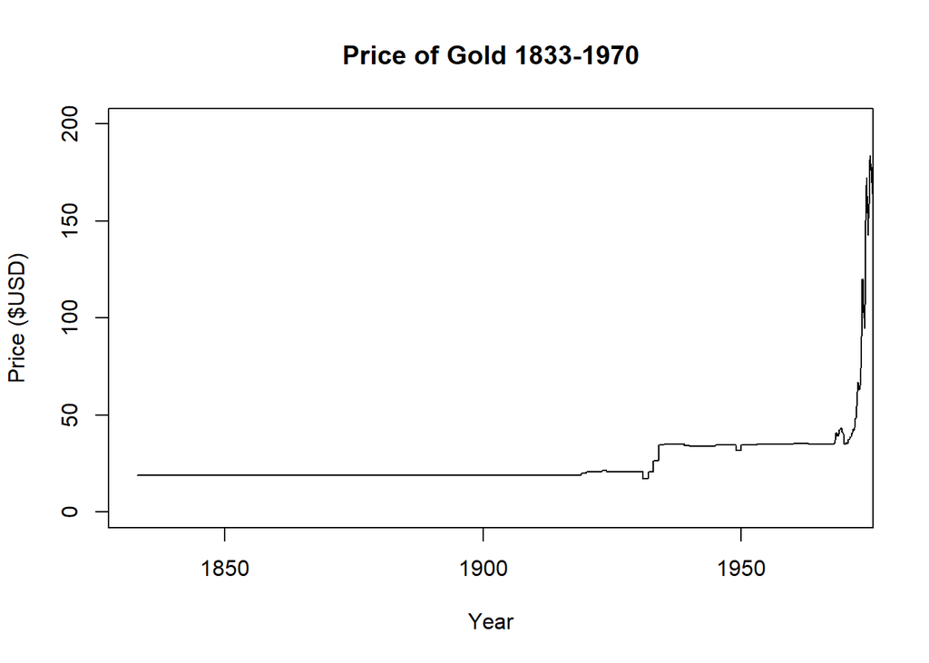

```r
# Focused Plots of Gold Prices 1833-1970

plot(gold_prophet$ds,
     gold_prophet$y,
     type="l",
     xlim= as.Date(c("1833-01-01", "1970-01-01")),
     ylim= c(0,200),
     main="Price of Gold 1833-1970",
     xlab="Year",
     ylab="Price ($USD)")
```

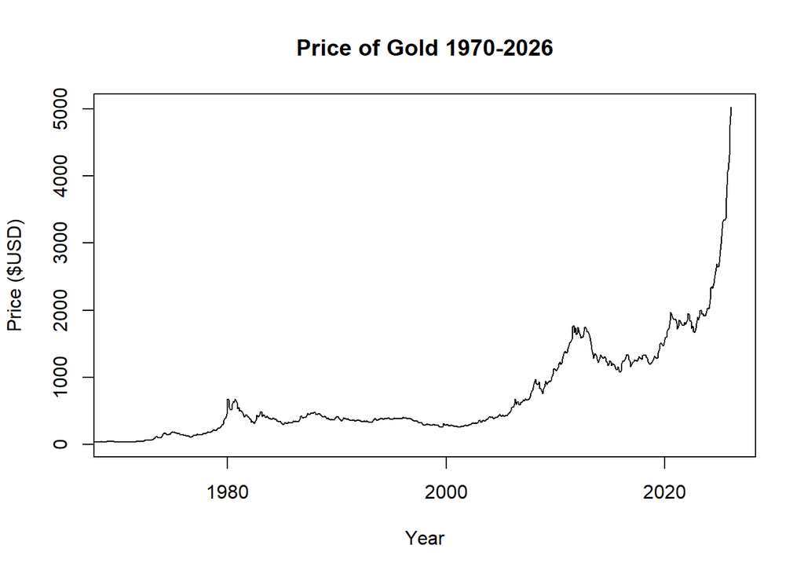

```r
# Focused Plots of Gold Prices 1970-2026

plot(gold_prophet$ds,
     gold_prophet$y,
     type="l",
     xlim= as.Date(c("1970-01-01", "2026-02-01")),
     main="Price of Gold 1970-2026",
     xlab="Year",
     ylab="Price ($USD)")
```

As shown in the graphs, it is evident that the price of gold has increased significantly since 1833. Until 1970, the price was generally fixed due to gold being a monetary standard as opposed to a commodity of fluctuating value. During the 1980’s, the price of gold rose dramatically for the first time, being a period of stagflation, characterised by slow economic growth and high inflation rates. This happened again in the late 2000’s due to the Global Financial Crisis, and once more in 2020 as a result of the pandemic and arising geopolitical tension.

# 4. Prophet Model

```r
gold_model <- prophet(gold_prophet)
```

```
## Disabling weekly seasonality. Run prophet with weekly.seasonality=TRUE to override this.
```

```
## Disabling daily seasonality. Run prophet with daily.seasonality=TRUE to override this.
```

# 5. Forecasting Gold Prices in Future Periods

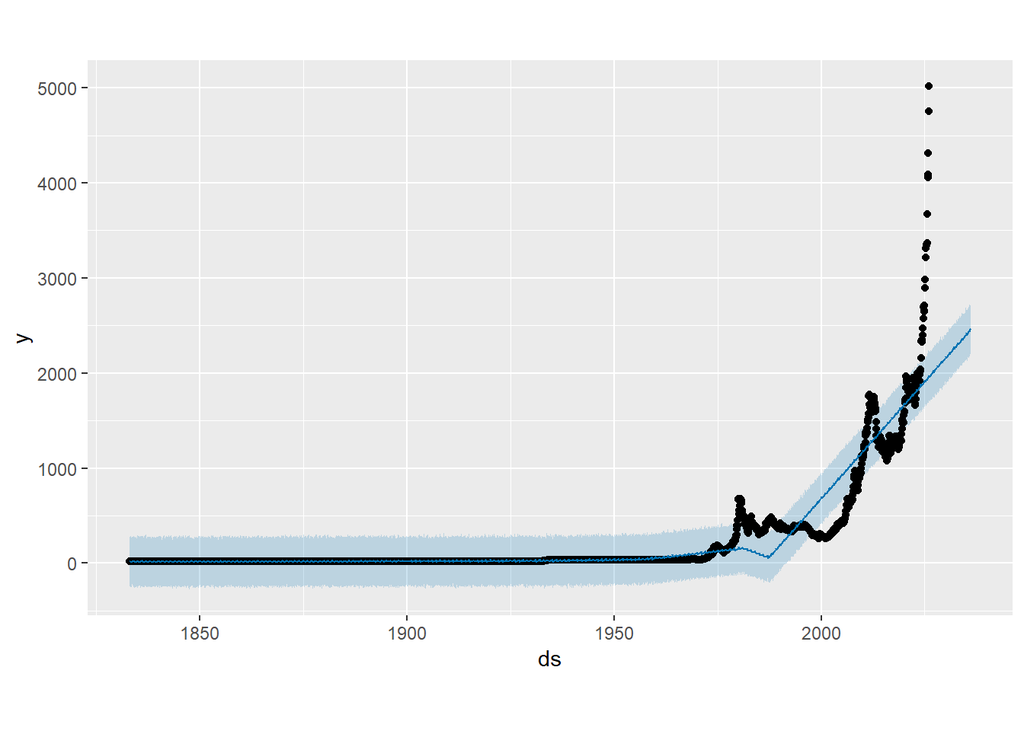

```r
future_price <- make_future_dataframe(gold_model, periods = 120, freq = "month")
forecast <- predict(gold_model, future_price)
plot(gold_model, forecast)
```

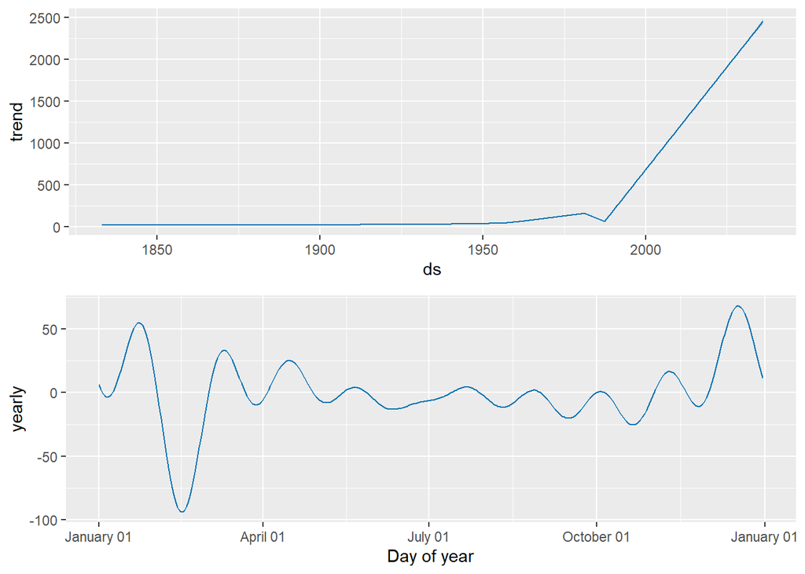

```r
prophet_plot_components(gold_model, forecast)
```